# NBI Training

Exercise 1 - Solved

## Welcome

Welcome to the first tutorial of the R Beginners Course of Spatial analysis. We hope that you are ready to try some things out!

## Outline

This tutorial is composed by one exercise:

- Populations in Finland and Sweden

After the completion of this tutorial you will be able to import, modify, and export data files.

## Popultions in Finland and Sweden

First we have to set the paths to the data.

```r
finland_path <- "C:/Users/R1_Exercise/Data/Part_1/Finland.csv"
sweden_path  <- "C:/Users/R1_Exercise/Data/Part_1/Sweden.csv"
```

Now we can read the files with the read.csv function.

```r
finland <- read.csv(finland_path, encoding = "latin1")
sweden  <- read.csv(sweden_path, encoding = "latin1")
```

We will add columns to both data frames that indicate the respective countries.

```r
finland$Country <- rep("Finland", times = nrow(finland))
sweden$Country  <- rep("Sweden", times = nrow(sweden))
```

Now we will use the *rbind* function to combine both data frames into a new one (**comb_df**).

```r
comb_df <- rbind(finland, sweden)
```

To order the resulting data frame from the largest to the smallest population, we will use the order function. This function will retrieve the positions of the elements according to population.

```r
new_order <- order(comb_df$Population, decreasing = TRUE)
print(new_order)
```

```
##   [1] 164   6  86 128   2  53 179  59  37  55 121 142 185  94 137  99  15 176
##  [19] 127  27  25  71  96  77 135  89  84 158 167 187  73 104  90 110 114  39
##  [37] 161  24  98 126  14 160 155 169  28 100 132  57   3 103 182 146  50 138
##  [55]  46  87  81 172 140 156 174 143  34 166  72  23  93  47  40 153 173 118
##  [73]  22 178 113 145   8 116  76  79  31 171 183  13 134 117  36  66 149  64
##  [91] 119 181  21 148 152  44  56  92  97 165 188  20  17 186 130 105 184  78
## [109] 180  16  35  62  80  49  74 101 106  18  63 136 190 102 177  85 150  61
## [127]  75 141  45 122  69 131  43 189  95 144 163  70 125  10 108 115  67 162
## [145] 157  91 124 175  41 129  48 111  42 120  29   7  68 151 168 107 147  88
## [163] 112  82  54  51   9 170  52  58  32  19  26 133  60 139  65  12   4  30
## [181] 154  11 159 123   1   5 109  38  83  33
```

Afterwards, we have to order the data frame according to these positions:

```r
comb_df <- comb_df[new_order, ]
head(comb_df)
```

```
##                       Name Population Country
## 164              Stockholm     975551  Sweden
## 6   Helsinki (Helsingfors)     653835 Finland
## 86   Göteborg [Gothenburg]     583056  Sweden
## 128                  Malmö     347949  Sweden
## 2             Espoo (Esbo)     289731 Finland
## 53                 Tampere     238140 Finland
```

```r
tail(comb_df)
```

```
##           Name Population Country
## 1    Aanekoski      18765 Finland
## 5      Heinola      18667 Finland
## 109   Kramfors      18133  Sweden
## 38  Pieksamaki      17682 Finland
## 83   Gällivare      17462  Sweden
## 33   Mariehamn      11679 Finland
```

Finally, we can export the data frame as a CSV file.

```r
write.csv(comb_df, "C:/Users/R1_Exercise/Data/Part_1/Output_data.csv")
```

To generate the two bar plots, we need to separate the *comb_df* object into two objects (one per country). Please note that we could alternatively use the *finland* and *sweden* objects but we want to practice what we learned! To acomplish this, we will ise the which function to assess which elements fulfill the required criteria.

```r
finland_five_pos <- which(comb_df$Country == "Finland")
sweden_five_pos  <- which(comb_df$Country == "Sweden")
print(finland_five_pos)
```

```
##  [1]   2   5   6   8   9  10  17  20  21  36  38  41  45  48  49  53  55  63  66
## [20]  68  69  73  77  81  84  87  93  96  97 102 103 110 111 112 114 118 126 129
## [39] 133 140 149 151 153 155 156 165 166 167 169 170 171 172 173 175 178 179 180
## [58] 182 185 186 188 190
```

```r
print(sweden_five_pos)
```

```
##   [1]   1   3   4   7  11  12  13  14  15  16  18  19  22  23  24  25  26  27
##  [19]  28  29  30  31  32  33  34  35  37  39  40  42  43  44  46  47  50  51
##  [37]  52  54  56  57  58  59  60  61  62  64  65  67  70  71  72  74  75  76
##  [55]  78  79  80  82  83  85  86  88  89  90  91  92  94  95  98  99 100 101
##  [73] 104 105 106 107 108 109 113 115 116 117 119 120 121 122 123 124 125 127
##  [91] 128 130 131 132 134 135 136 137 138 139 141 142 143 144 145 146 147 148
## [109] 150 152 154 157 158 159 160 161 162 163 164 168 174 176 177 181 183 184
## [127] 187 189
```

Then, we can subset the final elements by position using square brackets.

```r
finland_five <- comb_df[finland_five_pos,]
sweden_five  <- comb_df[sweden_five_pos,]
head(finland_five)
```

```
##                      Name Population Country
## 6  Helsinki (Helsingfors)     653835 Finland
## 2            Espoo (Esbo)     289731 Finland
## 53                Tampere     238140 Finland
## 59         Vantaa (Vanda)     233775 Finland
## 37                   Oulu     205489 Finland
## 55            Turku (Abo)     192962 Finland
```

```r
head(sweden_five)
```

```
##                      Name Population Country
## 164             Stockholm     975551  Sweden
## 86  Göteborg [Gothenburg]     583056  Sweden
## 128                 Malmö     347949  Sweden
## 179               Uppsala     233839  Sweden
## 121             Linköping     164616  Sweden
## 142                Örebro     156381  Sweden
```

Once the data is separated by country, we can use the order function to arrange the structure of the data frames from the city with the highest population to the lowest.

```r
finland_five <- finland_five[order(finland_five$Population, decreasing = TRUE),]
sweden_five  <- sweden_five[order(sweden_five$Population, decreasing = TRUE),]
head(finland_five)
```

```
##                      Name Population Country
## 6  Helsinki (Helsingfors)     653835 Finland
## 2            Espoo (Esbo)     289731 Finland
## 53                Tampere     238140 Finland
## 59         Vantaa (Vanda)     233775 Finland
## 37                   Oulu     205489 Finland
## 55            Turku (Abo)     192962 Finland
```

```r
head(sweden_five)
```

```
##                      Name Population Country
## 164             Stockholm     975551  Sweden
## 86  Göteborg [Gothenburg]     583056  Sweden
## 128                 Malmö     347949  Sweden
## 179               Uppsala     233839  Sweden
## 121             Linköping     164616  Sweden
## 142                Örebro     156381  Sweden
```

Once the objects are ordered, we have to subset only the first five elements from *finland_five* and *sweden_five* to obtain the five most populated cities per country.

```r
finland_five <- finland_five[1:5,]
sweden_five  <- sweden_five[1:5,]
print(finland_five)
```

```
##                      Name Population Country
## 6  Helsinki (Helsingfors)     653835 Finland
## 2            Espoo (Esbo)     289731 Finland
## 53                Tampere     238140 Finland
## 59         Vantaa (Vanda)     233775 Finland
## 37                   Oulu     205489 Finland
```

```r
print(sweden_five)
```

```
##                      Name Population Country
## 164             Stockholm     975551  Sweden
## 86  Göteborg [Gothenburg]     583056  Sweden
## 128                 Malmö     347949  Sweden
## 179               Uppsala     233839  Sweden
## 121             Linköping     164616  Sweden
```

Finally, we can generate the figures:

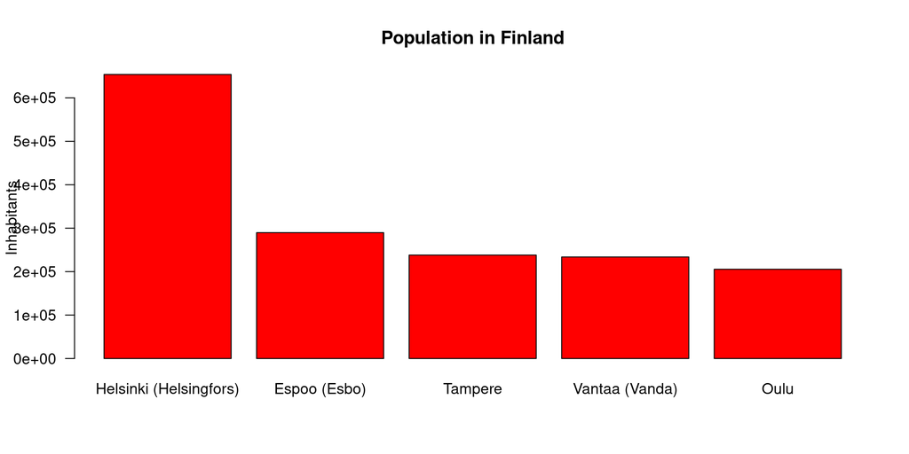

```r
barplot(finland_five$Population, main = "Population in Finland", ylab = "Inhabitants",
        col = "red", names.arg = finland_five$Name, las = 1)
```

Finally, we can generate the figures:

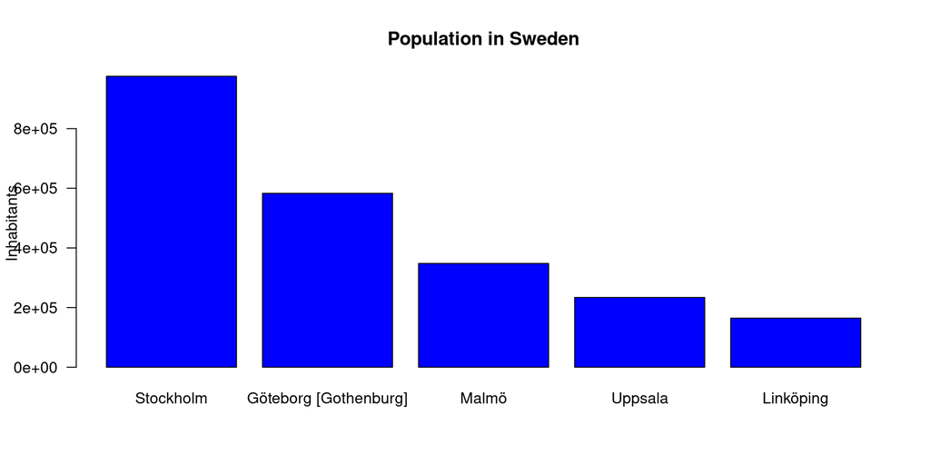

```r
barplot(sweden_five$Population, main = "Population in Sweden", ylab = "Inhabitants",
        col = "blue", names.arg = sweden_five$Name, las = 1)
```